# Simulations in R Part 4: Simulating Regression Models

Patrick Ward

7/12/2023

## Simulating Regression Models

Before delving into using simulation to check regression model assumptions, it might be useful to use a regression model reported in a research paper to simulate a data set. This can be useful if you are trying to better understand the paper (you can recalculate statistics and explore the data) or if you want to work on applying a different type of model approach to build hypotheses for future research.

I’m going to take the regression model from a paper by Ferrari et al. which looked to predict power lifting performance in male and female lifters.

[**Ferrari et al., (2022)., Performance and anthropometrics of classic powerlifters: Which characteristics matter? J Strength Cond Res.**](https://pubmed.ncbi.nlm.nih.gov/32187154/)

The paper used several variables to try and predict Squat, Bench, Deadlift, and Powerlifting Total in raw power lifters. To keep this simple, I’ll focus on the model for predicting squat performance, which was:

$Squat = -145.7 + 4.3*Years.Experience - 1.7*BF.Pct + 6*Upper.Arm.Girth + 1.9*Thigh.Girth$

The model had a standard error of estimate (SEE) of 20.3 and an r-squared of 0.83.

## Getting the necessary info from the paper

Aside from the model coefficients, above, we also need to get the mean and standard deviation for each of the variables in the model (for both male and female lifters). We will use those parameters to simulate 1000 male and female lifters.

```r
library(tidyverse)
# set the see for reproducibility
set.seed(82)

# sample size - simulate 1000 male and 1000 female lifters
n_males <- 1000
n_females <- 1000

# set the model coefficients for squats
intercept <- -145.7
years_exp_beta <- 4.3
pct_bf_beta <- -1.7
upper_arm_girth_beta <- 6
thigh_girth_beta <- 1.9

# Standard Error of Estimate (SEE) is sampled from a normal distribution with a mean = 0 and
# standard deviation of 20.3
see <- rnorm(n = n_males + n_females, mean = 0, sd = 20.3)

# get mean and sd for each of the model variables
years_exp_male <- rnorm(n = n_males, mean = 2.6, sd = 2.4)
years_exp_male <- ifelse(years_exp_male < 0, 0, years_exp_male)
years_exp_female <- rnorm(n = n_females, mean = 1.6, sd = 1.5)
years_exp_female <- ifelse(years_exp_female < 0, 0, years_exp_female)
pct_bf_male <- rnorm(n = n_males, mean = 11.1, sd = 3.8)
pct_bf_female <- rnorm(n = n_females, mean = 21.7, sd = 5.4)
upper_arm_girth_male <- rnorm(n = n_males, mean = 35.6, sd = 2.8)
upper_arm_girth_female <- rnorm(n = n_females, mean = 29.5, sd = 3.1)
thigh_girth_male <- rnorm(n = n_males, mean = 61.1, sd = 5.5)
thigh_girth_female <- rnorm(n = n_females, mean = 56.1, sd = 4.9)

# put the simulated data into a data frame
dat <- data.frame(
  gender = c(rep("male", times = n_males), rep("female", times = n_females)),
  years_exp = c(years_exp_male, years_exp_female),
  pct_bf = c(pct_bf_male, pct_bf_female),
  upper_arm_girth = c(upper_arm_girth_male, upper_arm_girth_female),
  thigh_girth = c(thigh_girth_male, thigh_girth_female)
)

dat %>%
  head()
```

```
##   gender years_exp    pct_bf upper_arm_girth thigh_girth
## 1   male 0.5360737 10.936874        34.71180    68.41175
## 2   male 3.0800143 13.244026        37.50158    61.36915
## 3   male 2.6958622 17.468022        31.75833    64.46085
## 4   male 1.3195369  6.454256        36.14391    60.06982
## 5   male 3.4157072 12.488050        38.22546    61.07867
## 6   male 0.9329759 15.159396        33.20791    64.86337
```

```r
## check means and standard deviations of the simulation
dat %>%
  group_by(gender) %>%
  summarize(across(.cols = years_exp:thigh_girth,
                   list(avg = mean, SD = sd)),
            .groups = "drop") %>%
  pivot_longer(cols = -gender)
```

```
## # A tibble: 16 × 3
##    gender name                value
##    <chr>  <chr>               <dbl>
##  1 female years_exp_avg        1.68
##  2 female years_exp_SD         1.25
##  3 female pct_bf_avg          21.9
##  4 female pct_bf_SD            5.51
##  5 female upper_arm_girth_avg 29.4
##  6 female upper_arm_girth_SD   3.13
##  7 female thigh_girth_avg     56.1
##  8 female thigh_girth_SD       4.75
##  9 male   years_exp_avg        2.81
## 10 male   years_exp_SD         2.14
## 11 male   pct_bf_avg          11.1
## 12 male   pct_bf_SD            3.71
## 13 male   upper_arm_girth_avg 35.6
## 14 male   upper_arm_girth_SD   2.78
## 15 male   thigh_girth_avg     61.1
## 16 male   thigh_girth_SD       5.53
```

## Estimate squat performance using the model

Next, we use the values that we simulated and the model coefficients to simulate the outcome of interest (Squat performance).

```r
# estimate squat performance
dat$squat <- with(dat, intercept + years_exp_beta*years_exp + pct_bf_beta*pct_bf + upper_arm_girth_beta*upper_arm_girth + thigh_girth_beta*thigh_girth + see)

dat %>%
  head()
```

```
##   gender years_exp    pct_bf upper_arm_girth thigh_girth    squat
## 1   male 0.5360737 10.936874        34.71180    68.41175 151.5090
## 2   male 3.0800143 13.244026        37.50158    61.36915 192.7973
## 3   male 2.6958622 17.468022        31.75833    64.46085 142.5135
## 4   male 1.3195369  6.454256        36.14391    60.06982 151.5132
## 5   male 3.4157072 12.488050        38.22546    61.07867 197.6507
## 6   male 0.9329759 15.159396        33.20791    64.86337 146.1015
```

```r
## summary statistics
dat %>%
  group_by(gender) %>%
  summarize(avg_squat = mean(squat),
            sd_squat = sd(squat))
```

```
## # A tibble: 2 × 3
##   gender avg_squat sd_squat
##   <chr>      <dbl>    <dbl>
## 1 female      107.     31.2
## 2 male        177.     30.2
```

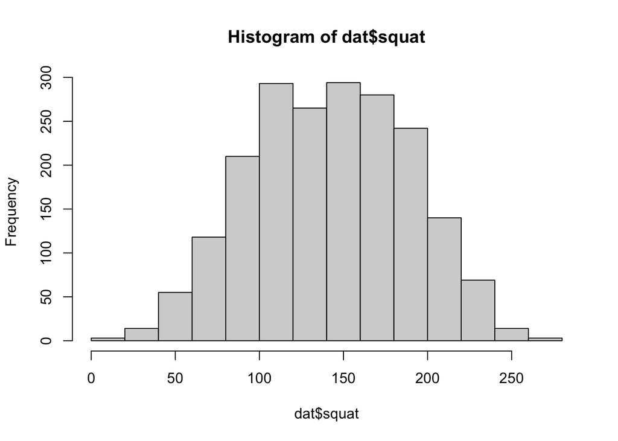

```r
# plots
hist(dat$squat)
```

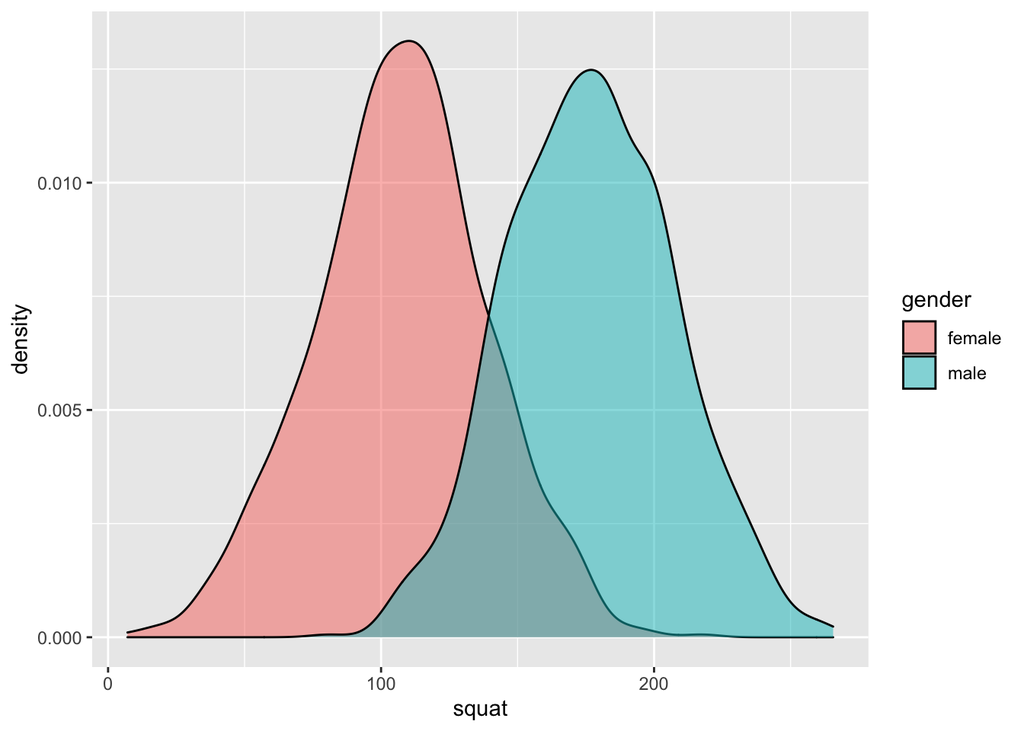

```r
dat %>%
  ggplot(aes(x = squat, fill = gender)) +
  geom_density(alpha = 0.5)
```

## Look at the regression model

```r
fit_lm <- lm(squat ~ years_exp + pct_bf + upper_arm_girth + thigh_girth, data = dat)
summary(fit_lm)
```

```
##
## Call:
## lm(formula = squat ~ years_exp + pct_bf + upper_arm_girth + thigh_girth,
##     data = dat)
##
## Residuals:
##     Min      1Q  Median      3Q     Max
## -66.700 -13.980   0.026  13.936  62.111
##
## Coefficients:
##                   Estimate Std. Error t value Pr(>|t|)
## (Intercept)     -145.15227    6.68876  -21.70   <2e-16 ***
## years_exp          4.50781    0.25520   17.66   <2e-16 ***
## pct_bf            -1.71528    0.07730  -22.19   <2e-16 ***
## upper_arm_girth    6.07255    0.12872   47.18   <2e-16 ***
## thigh_girth        1.84422    0.08453   21.82   <2e-16 ***
## ---
## Signif. codes:  0 '***' 0.001 '**' 0.01 '*' 0.05 '.' 0.1 ' ' 1
##
## Residual standard error: 20.29 on 1995 degrees of freedom
## Multiple R-squared:  0.8095, Adjusted R-squared:  0.8091
## F-statistic:  2119 on 4 and 1995 DF,  p-value: < 2.2e-16
```

- The coefficients are as expected
- The standard error (Residual standard error) is 20.3, as expected
- The r-squared for the model is 0.81

## Making a better simulation

```r
dat %>%
  group_by(gender) %>%
  summarize(avg_squat_sim = mean(squat),
            sd_squat_sim = sd(squat)) %>%
  mutate(avg_squat_paper = c(118.3, 196.1),
         sd_squat_paper = c(26.6, 37.9))
```

```
## # A tibble: 2 × 5
##   gender avg_squat_sim sd_squat_sim avg_squat_paper sd_squat_paper
##   <chr>          <dbl>        <dbl>           <dbl>          <dbl>
## 1 female          107.         31.2            118.           26.6
## 2 male            177.         30.2            196.           37.9
```

Our estimates are a little low relative to what was reported in the paper. The model above still works because we constructed it with the regression coefficients and variable parameters in the model, so we can still *play with the data* and learn something. But, the estimated squats might be a little low because the anthropometric variables in the model (BF%, Upper Arm Girth, and Thigh Girth) are in some way going to be correlated with each other. So, we could make this simulation more informative by simulating those variables from a multivariate normal distribution, as we did in Part 3.

To start, we load the `mvtnorm` package and set up a vector of mean values for each variable. We will construct a vector for males and females separately. We will use the mean values for each variable reported in the paper.

```r
library(mvtnorm)

## Order of means is: BF%, Upper Arm Girth, Thigh Girth
male_means <- c(11.1, 35.6, 61.1)
female_means <- c(21.7, 29.5, 56.1)
```

Next, we need to construct a correlation matrix between these three variables. Again, we will create a correlation matrix for males and females, separately. I’m not sure of the exact correlation between these variables, so I’ll just estimate what I believe it to be. For example, the correlations probably aren’t 0.99 but they also probably aren’t below 0.6. I’m also unsure how these correlations might differ between the two genders. Thus, I’ll keep the same correlation matrix for both. To keep it simple, I’ll set the correlation between BF% and upper arm and thigh girth at 0.85 and the correlation between upper arm girth and thigh girth to be 0.9. In theory, we could consult some scientific literature on these things and attempt to construct more plausible correlations.

```r
## Create correlation matrices
# males
male_r_matrix <- matrix(c(1, 0.85, 0.85,
                          0.85, 1, 0.9,
                          0.85, 0.9, 1),
                   nrow = 3, ncol = 3,
       dimnames = list(c("bf_pct", "upper_arm_girth", "thigh_girth"),
                       c("bf_pct", "upper_arm_girth", "thigh_girth")))

male_r_matrix
```

```
##                 bf_pct upper_arm_girth thigh_girth
## bf_pct            1.00            0.85        0.85
## upper_arm_girth   0.85            1.00        0.90
## thigh_girth       0.85            0.90        1.00
```

```r
# females
female_r_matrix <- matrix(c(1, 0.85, 0.85,
                          0.85, 1, 0.9,
                          0.85, 0.9, 1),
                   nrow = 3, ncol = 3,
       dimnames = list(c("bf_pct", "upper_arm_girth", "thigh_girth"),
                       c("bf_pct", "upper_arm_girth", "thigh_girth")))

female_r_matrix
```

```
##                 bf_pct upper_arm_girth thigh_girth
## bf_pct            1.00            0.85        0.85
## upper_arm_girth   0.85            1.00        0.90
## thigh_girth       0.85            0.90        1.00
```

Now we will create 1000 simulations from a multivariate normal distribution for both males and females and then row bind them together into a single big data frame.

```r
## simulate 1000 new x, y, and z variables using the mvtnorm package
set.seed(777)
male_sim <- rmvnorm(n = n_males, mean = male_means, sigma = male_r_matrix) %>%
  as.data.frame() %>%
  setNames(c("pct_bf", "upper_arm_girth", "thigh_girth"))

female_sim <- rmvnorm(n = n_females, mean = female_means, sigma = female_r_matrix) %>%
  as.data.frame() %>%
  setNames(c("pct_bf", "upper_arm_girth", "thigh_girth"))

head(male_sim)
```

```
##     pct_bf upper_arm_girth thigh_girth
## 1 11.54419        35.72831    61.51588
## 2 11.70793        37.00773    62.18599
## 3 11.63691        36.45526    61.53937
## 4 10.68901        35.23088    60.84422
## 5 10.51125        35.87598    62.11762
## 6 12.06327        36.50208    61.52498
```

```r
head(female_sim)
```

```
##     pct_bf upper_arm_girth thigh_girth
## 1 20.20095        27.08319    53.44510
## 2 23.01118        30.23862    56.65550
## 3 19.52359        27.20464    54.24450
## 4 20.33838        28.18756    54.72508
## 5 21.18905        29.23823    55.62311
## 6 21.72806        29.46231    55.78229
```

```r
## put the two simulated data frames together
multi_sims <- bind_rows(male_sim, female_sim)
multi_sims %>%
  head()
```

```
##     pct_bf upper_arm_girth thigh_girth
## 1 11.54419        35.72831    61.51588
## 2 11.70793        37.00773    62.18599
## 3 11.63691        36.45526    61.53937
## 4 10.68901        35.23088    60.84422
## 5 10.51125        35.87598    62.11762
## 6 12.06327        36.50208    61.52498
```

Finally, one last thing we’ll change is our simulation of years of experience. This variable is not a normally distributed variable because it is truncated at 0. Above, in our first simulation, we attempted to solve this with the `ifelse()` expression to assign any simulated value less than 0 to 0. Here, I’ll just get the quantiles of the simulated years of experience so that I have an idea of a plausible upper end of experience for the population used in this paper. Then, instead of simulating from a normal distribution I’ll do a random draw from a uniform distribution from 0 to the respective upper end for the male and female groups.

```r
# Quantiles of years experience simulation from above to get the upper end
quantile(dat$years_exp[dat$gender == "male"])
```

```
##        0%       25%       50%       75%      100%
##  0.000000  1.067894  2.649636  4.227022 10.866586
```

```r
quantile(dat$years_exp[dat$gender == "female"])
```

```
##        0%       25%       50%       75%      100%
## 0.0000000 0.6112886 1.6475260 2.5185795 6.5252171
```

```r
# Simulate years of experience from a uniform distribution
set.seed(8801)
years_exp_male <- runif(n = n_males, min = 0, max = 11)
years_exp_female <- runif(n = n_females, min = 0, max = 7)
```

Now take the newly simulated variables and create a new data frame.

```r
## new data frame
new_dat <- data.frame(
  gender = c(rep("male", times = n_males), rep("female", times = n_females)),
  years_exp = c(years_exp_male, years_exp_female)
) %>%
  bind_cols(multi_sims)

new_dat %>%
  head()
```

```
##   gender  years_exp   pct_bf upper_arm_girth thigh_girth
## 1   male  0.5746726 11.54419        35.72831    61.51588
## 2   male  5.3193257 11.70793        37.00773    62.18599
## 3   male  1.8804160 11.63691        36.45526    61.53937
## 4   male  1.8605587 10.68901        35.23088    60.84422
## 5   male  7.6814169 10.51125        35.87598    62.11762
## 6   male 10.7017614 12.06327        36.50208    61.52498
```

Finally, go through the steps we did above to estimate the squat from our four variables and the beta coefficients from the paper.

```r
# estimate squat performance
new_dat$squat <- with(new_dat, intercept + years_exp_beta*years_exp + pct_bf_beta*pct_bf + upper_arm_girth_beta*upper_arm_girth + thigh_girth_beta*thigh_girth + see)

new_dat %>%
  head()
```

```
##   gender  years_exp   pct_bf upper_arm_girth thigh_girth    squat
## 1   male  0.5746726 11.54419        35.72831    61.51588 143.6394
## 2   male  5.3193257 11.70793        37.00773    62.18599 203.6266
## 3   male  1.8804160 11.63691        36.45526    61.53937 171.5507
## 4   male  1.8605587 10.68901        35.23088    60.84422 142.6337
## 5   male  7.6814169 10.51125        35.87598    62.11762 207.2309
## 6   male 10.7017614 12.06327        36.50208    61.52498 206.7928
```

```r
## summary statistics
new_dat %>%
  group_by(gender) %>%
  summarize(avg_squat = mean(squat),
            sd_squat = sd(squat))
```

```
## # A tibble: 2 × 3
##   gender avg_squat sd_squat
##   <chr>      <dbl>    <dbl>
## 1 female      116.     23.5
## 2 male        189.     24.9
```

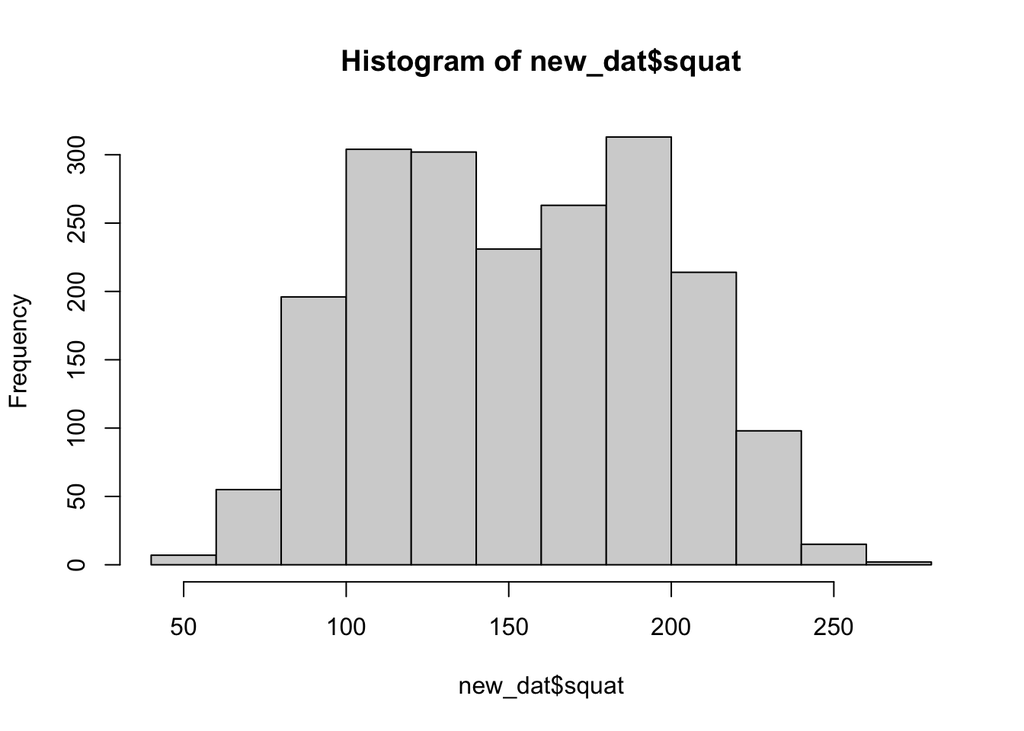

```r
# plots
hist(new_dat$squat)
```

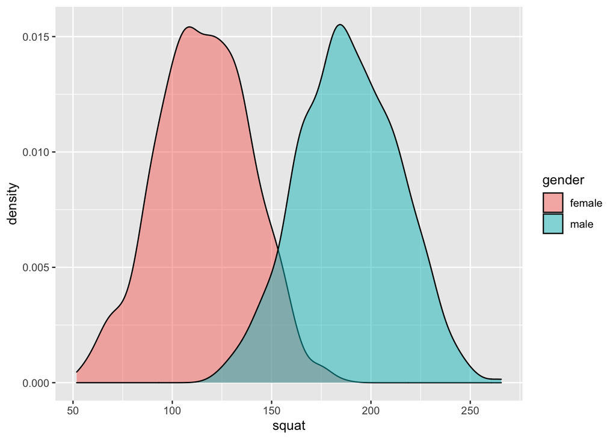

```r
new_dat %>%
  ggplot(aes(x = squat, fill = gender)) +
  geom_density(alpha = 0.5)
```

## Look at the new regression model

```r
fit_lm_new <- lm(squat ~ years_exp + pct_bf + upper_arm_girth + thigh_girth, data = new_dat)
summary(fit_lm_new)
```

```
##
## Call:
## lm(formula = squat ~ years_exp + pct_bf + upper_arm_girth + thigh_girth,
##     data = new_dat)
##
## Residuals:
##     Min      1Q  Median      3Q     Max
## -67.059 -14.156  -0.027  13.952  63.016
##
## Coefficients:
##                  Estimate Std. Error t value Pr(>|t|)
## (Intercept)     -140.6387    32.9282  -4.271 2.04e-05 ***
## years_exp          4.2179     0.1685  25.029  < 2e-16 ***
## pct_bf            -1.5598     0.1846  -8.450  < 2e-16 ***
## upper_arm_girth    6.7554     1.0164   6.646 3.86e-11 ***
## thigh_girth        1.3586     1.0777   1.261    0.208
## ---
## Signif. codes:  0 '***' 0.001 '**' 0.01 '*' 0.05 '.' 0.1 ' ' 1
##
## Residual standard error: 20.29 on 1995 degrees of freedom
## Multiple R-squared:  0.7862, Adjusted R-squared:  0.7858
## F-statistic:  1834 on 4 and 1995 DF,  p-value: < 2.2e-16
```

## Compare the squat simulated data to that which was reported in the paper

```r
new_dat %>%
  group_by(gender) %>%
  summarize(avg_squat_sim = mean(squat),
            sd_squat_sim = sd(squat)) %>%
  mutate(avg_squat_paper = c(118.3, 196.1),
         sd_squat_paper = c(26.6, 37.9))
```

```
## # A tibble: 2 × 5
##   gender avg_squat_sim sd_squat_sim avg_squat_paper sd_squat_paper
##   <chr>          <dbl>        <dbl>           <dbl>          <dbl>
## 1 female          116.         23.5            118.           26.6
## 2 male            189.         24.9            196.           37.9
```

Now we have mean values much closer to those observed in the population of the study. Our standard deviations differ from the study because, if you recall, the standard error of the estimate was 20.3 for the regression model. The model in the study did not include gender as an independent variable. This to me is a little strange and in the discussion of the paper the authors’ also indicate that it was strange to them too. However, the approach the authors’ took to building this deemed gender unnecessary as a predictor variable. Consequently, our simulation has a similar standard deviation in estimate squat for both the male and female populations. However, we now have a data set that is relatively close to what was observed in the paper and can therefore proceed with conducting other statistical tests or building other models.